# Post-processing Report

# Maternal Mortality Post-Processing

This report reproduces all analysis steps with plots shown inline.

## Model Specification

We model maternal mortality in each region $i$ using a Bayesian hierarchical framework based on the structure proposed by *Stoner et al. (2019)*.

### **1. Data Generating Process**

We assume the **true number of maternal deaths** is $y_i$, and that only a fraction $\pi_i$ of these are reported as observed deaths $z_i$:

$$y_i \sim \text{Poisson}(\lambda_i)$$
$$z_i \sim \text{Binomial}(y_i, \pi_i)$$

This reflects underreporting of maternal deaths, where $\pi_i$ is the reporting probability in region $i$.

**Note**: In the implementation, we marginalize over $y_i$, resulting in:

$$z_i \sim \text{Poisson}(\pi_i \cdot \lambda_i)$$

### **2. Incidence Model (log-linear)**

We model the maternal death rate $\lambda_i$ as a function of live births and risk covariates:

$$\log(\lambda_i) = \log(\text{live\_births}_i) + \alpha_0 + \alpha_1
\cdot \texttt{educ}_i + \alpha_2 \cdot \texttt{travel}_i + \alpha_3
\cdot \texttt{anc4}_i + \phi_i + \theta_i$$

- $\texttt{educ}_i$: education covariate
- $\texttt{travel}_i$: travel time to nearest health facility
- $\texttt{anc4}_i$: ANC 4+ visits
- $\phi_i$: spatially structured random effect (ICAR)
- $\theta_i$: unstructured noise

### **3. Reporting Model (logistic)**

The reporting probability $\pi_i$ is modeled on the logit scale:

$$\text{logit}(\pi_i) = \beta_0 + \beta_1 \cdot \texttt{ancRef}_i +
\gamma_i$$

- $\texttt{ancRef}_i$: reporting covariate (e.g., community engagement or ANC reference)
- $\gamma_i$: region-specific noise in reporting

### **4. Priors**

All parameters are estimated via Bayesian inference in **NIMBLE**, following the hierarchical structure proposed by *Stoner et al. (2019)*.

```r
#################################################################
##   LGA estimates of community MMR                            ##
##   4. Post-processing                                        ##
##   Purpose: Fit checks and post-processing of raw model      ##
##            model output data                                ##
##   Author: Anu Mishra                                        ##
##   Created 6/9/25                                            ##
#################################################################
rm(list=ls())
```

```r
library(tidyverse)
```

```r
library(ggplot2)
library(nimble)
library(coda) # For manipulation of MCMC results.
library(sf)
library(gridExtra)
library(patchwork)
library(ggrepel)
```

```r
source("~/GitHub/CBHMIS_SAE_MMR/0_functions.R", echo=TRUE)
```

```
##
## > summarize_draws <- function(samples_matrix, param_name) {
## +     colnames(samples_matrix) <- paste0(param_name, "_", seq_len(ncol(samples_matrix)))
## + .... [TRUNCATED]
##
## > plot_prior_vs_posterior <- function(samples, param_name,
## +     prior_defs) {
## +     post <- unlist(lapply(samples, function(chain) chain[, param_nam .... [TRUNCATED]
```

```r
setwd("C:/Users/anumi/OneDrive - Bill & Melinda Gates Foundation/Documents/GitHub/CBHMIS_SAE_MMR")
```

```r
model_date <- "2025-06-30"
model_output <- paste0("model_out_",model_date,".rds")  ## which version of the model you want to read in
model_out_dir <- paste0("model runs/model_",model_date,"/")
```

```r
#### Loading data ####
## model output
full_out <- readRDS(paste0(model_out_dir,"/",model_output))
samples <- full_out$samples
```

```r
## shape file
nga_shp <- st_read("raw data/gadm41_NGA_shp/gadm41_NGA_2.shp")
kdn_shp <- nga_shp[nga_shp$NAME_1=="Kaduna",]
kdn_shp$NAME_2 <- gsub(pattern = " ",replacement = "_", kdn_shp$NAME_2)
kdn_shp$NAME_2 <- gsub(pattern = "'",replacement = "", kdn_shp$NAME_2)
```

```r
## CBHMIS data
data <- read.csv("cbhmis_data_for_model.csv")
load("nimble_inputs_final.RData")
LGA_names <- data$LGA
LGA_names2 <- data.frame("LGA"=1:23,"name"=LGA_names)
```

```r
#### 1: Model Diagnostics and Convergence ####
```

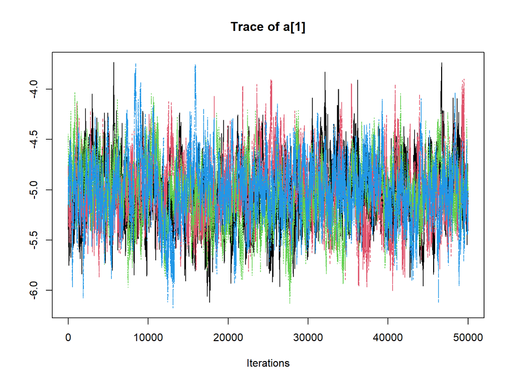

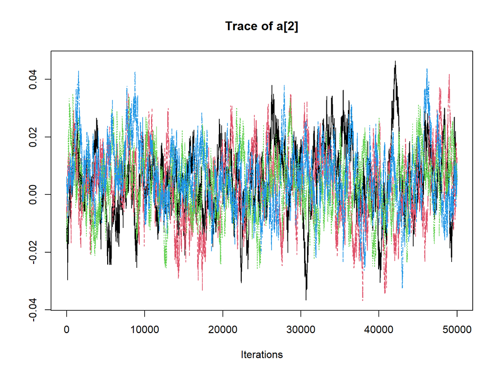

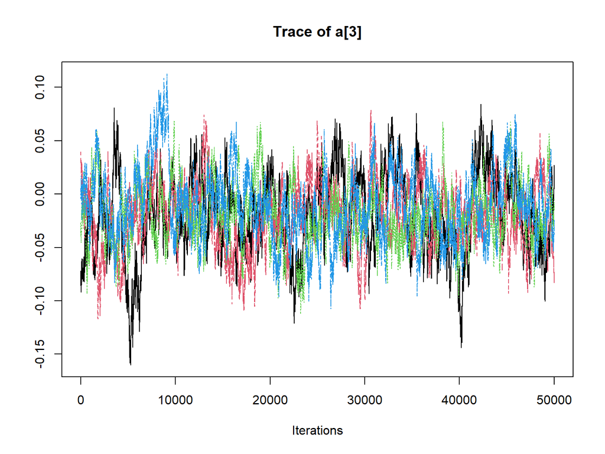

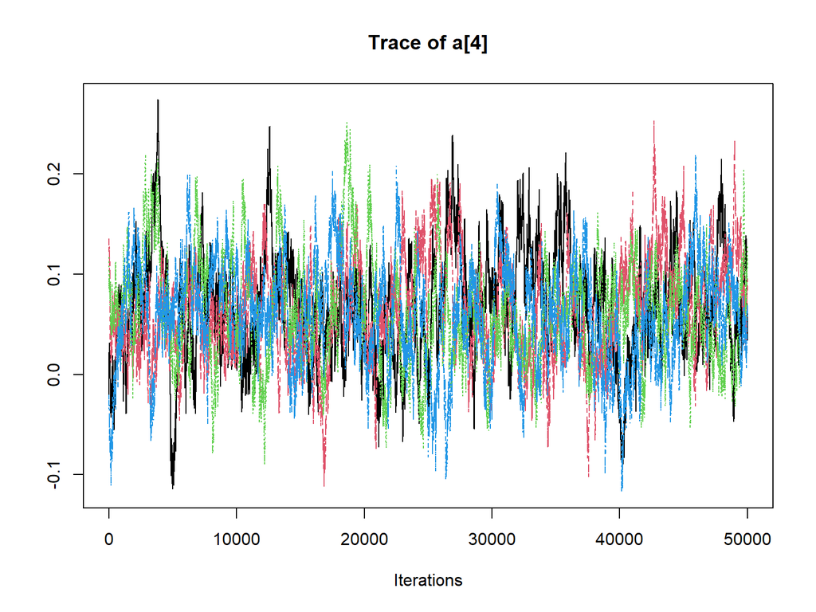

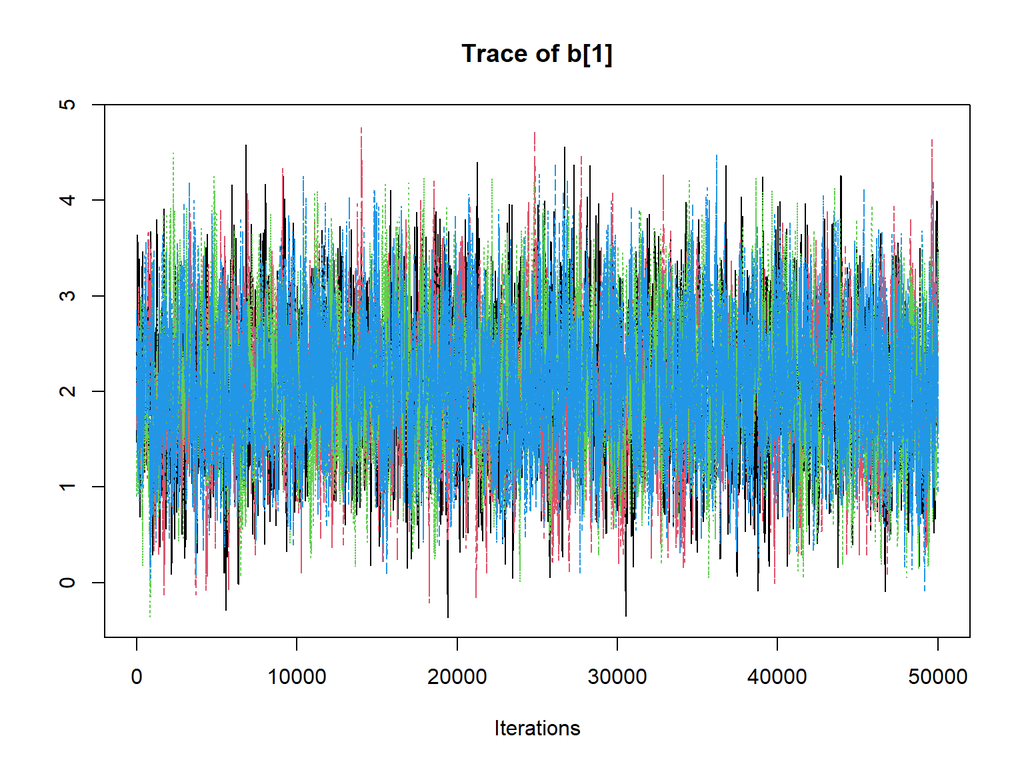

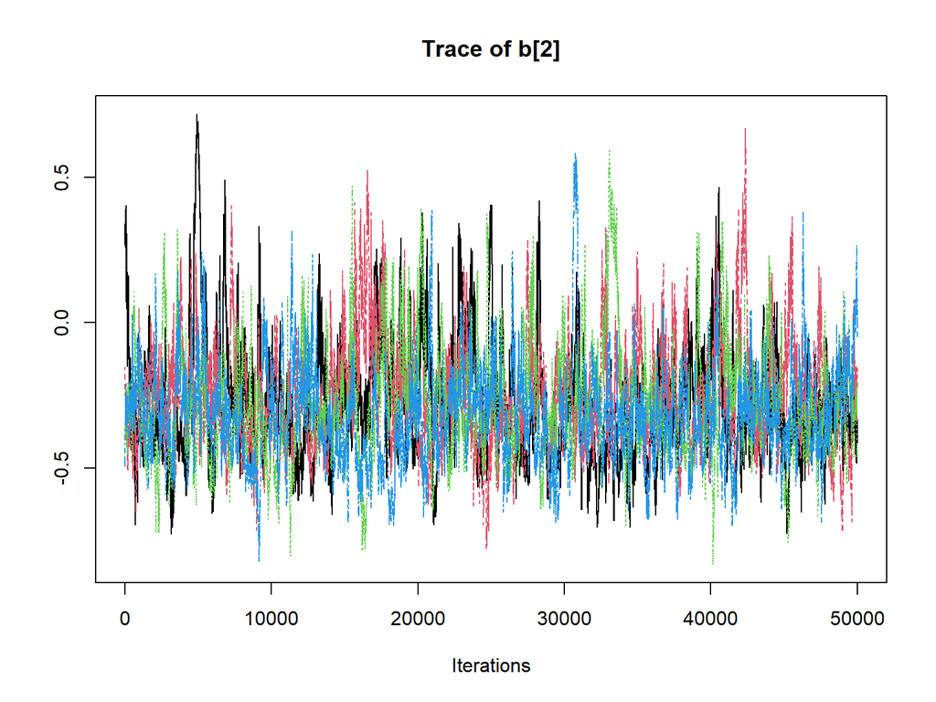

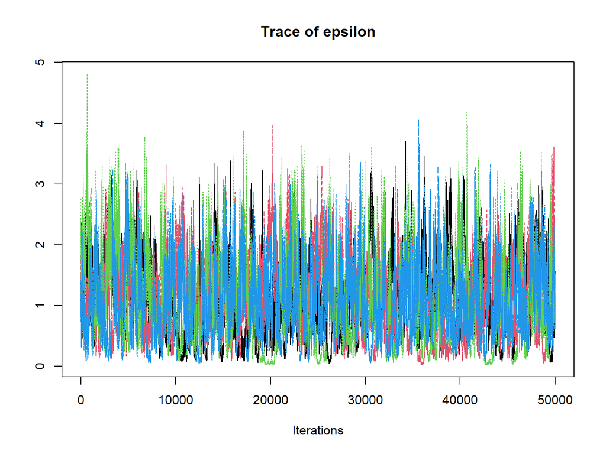

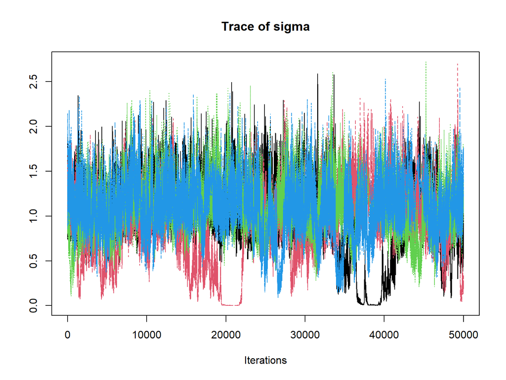

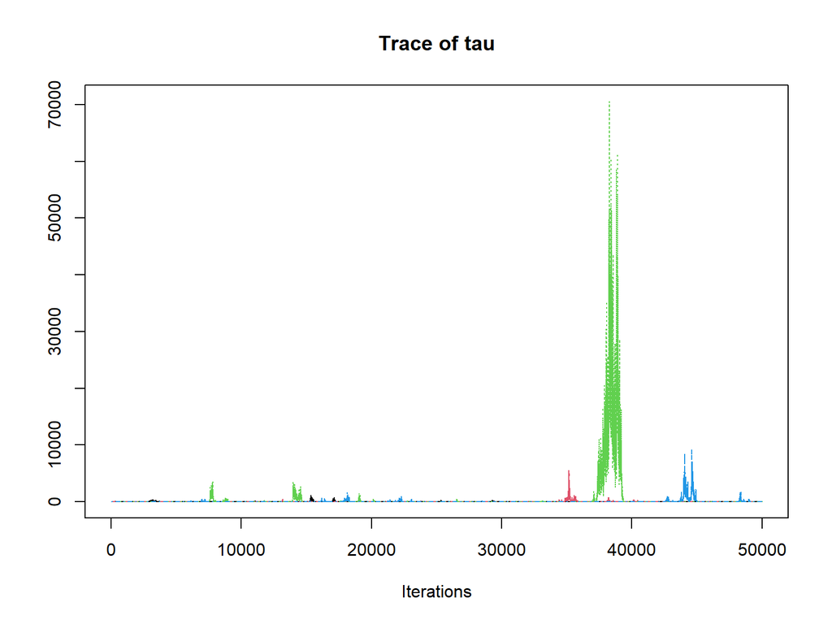

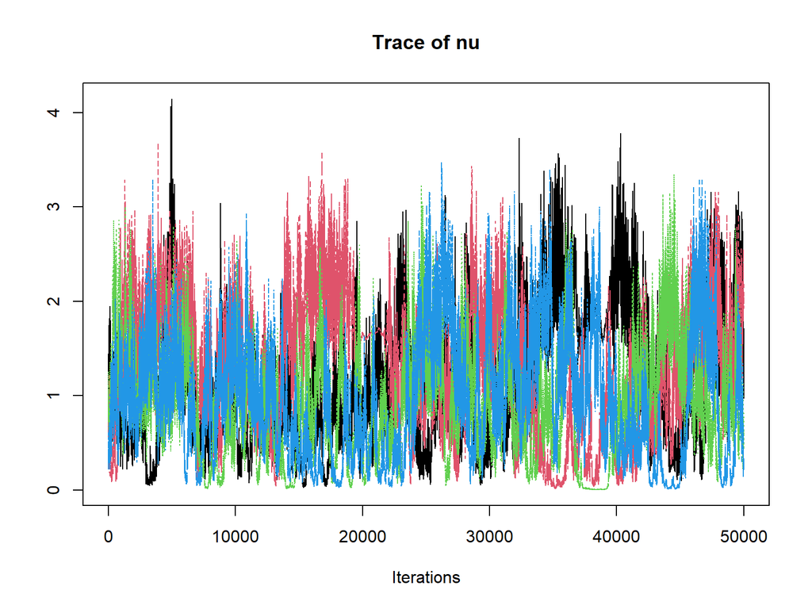

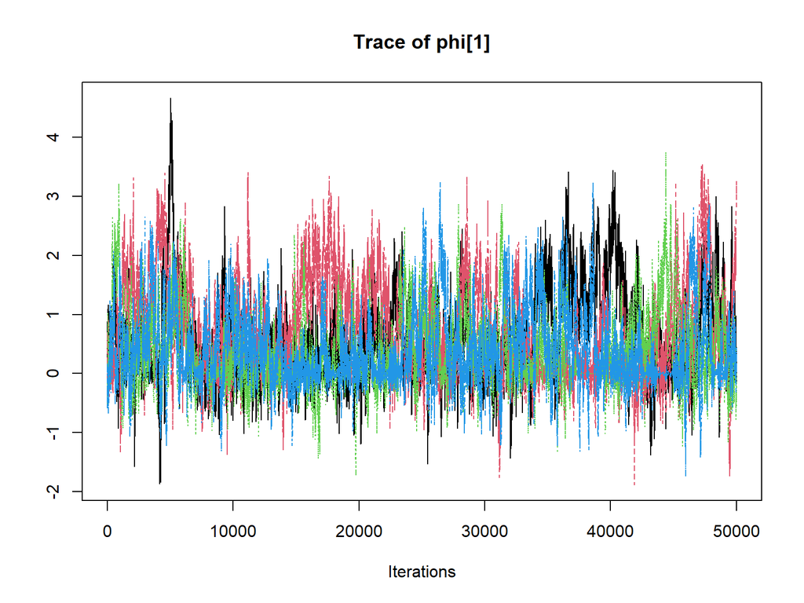

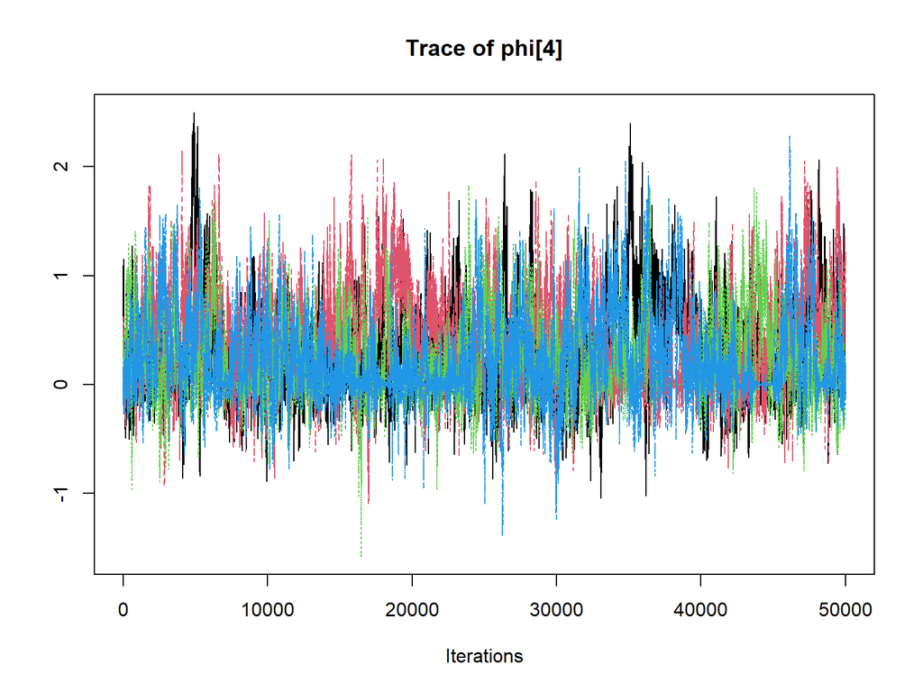

[5 more figures not shown]

```r
# traceplots and convergence
traceplot(samples[,c('a[1]','a[2]','a[3]','a[4]',
                         'b[1]','b[2]',
                         'epsilon','sigma','tau','nu',
                         'phi[1]','phi[4]','phi[8]','phi[10]','phi[12]','phi[17]','phi[23]')])
```

```r
### Adding a couple of phis because tau looks bad but nu looks ok --> phi's seem to be mixing well
```

```r
gelman.diag(samples[,c('a[1]','a[2]','a[3]','a[4]',
                       'b[1]','b[2]',
                       'epsilon','sigma','tau','nu',
                       'phi[1]','phi[4]','phi[8]','phi[10]','phi[12]','phi[17]','phi[23]')])
```

```
## Potential scale reduction factors:
##
##         Point est. Upper C.I.
## a[1]          1.00       1.01
## a[2]          1.03       1.08
## a[3]          1.03       1.05
## a[4]          1.06       1.16
## b[1]          1.00       1.00
## b[2]          1.03       1.08
## epsilon       1.02       1.06
## sigma         1.10       1.24
## tau           1.31       2.26
## nu            1.06       1.17
## phi[1]        1.03       1.08
## phi[4]        1.01       1.03
## phi[8]        1.01       1.02
## phi[10]       1.02       1.05
## phi[12]       1.04       1.10
## phi[17]       1.00       1.01
## phi[23]       1.03       1.07
##
## Multivariate psrf
##
## 1.12
```

```r
effectiveSize(samples[,c('a[1]','a[2]','a[3]','a[4]',
                         'b[1]','b[2]',
                         'epsilon','sigma','tau','nu',
                         'phi[1]','phi[4]','phi[8]','phi[10]','phi[12]','phi[17]','phi[23]')])
```

```
##      a[1]      a[2]      a[3]      a[4]      b[1]      b[2]   epsilon     sigma
##  899.2374  291.3560  327.9108  331.4724 3139.2706  616.8886  671.7202  457.8616
##       tau        nu    phi[1]    phi[4]    phi[8]   phi[10]   phi[12]   phi[17]
##  626.5073  243.1071  752.6851 1235.7010 1193.7715  504.6683 1035.9474 1861.2066
##   phi[23]
##  468.7898
```

```r
#### 2: Prior checks ####
## prior vs posterior
param_names <- c('a[1]', 'a[2]', 'a[3]', 'a[4]',
                 'b[1]', 'b[2]', 'epsilon', 'sigma', 'nu')
```

```r
prior_defs <- list(
  "a[1]" = list(type = "norm", mean = 0, sd = 10),
  "a[2]" = list(type = "norm", mean = 0, sd = 10),
  "a[3]" = list(type = "norm", mean = 0, sd = 10),
  "a[4]" = list(type = "norm", mean = 0, sd = 10),
  "b[1]" = list(type = "norm", mean = 2, sd = 0.6),
  "b[2]" = list(type = "norm", mean = 0, sd = 10),
  "epsilon" = list(type = "half-normal", mean = 0, sd = 1),  # tighter prior, often used in under-reporting
  "sigma" = list(type = "half-normal", mean = 0, sd = 1),
  "nu" = list(type = "half-normal", mean = 0, sd = 1)
)
```

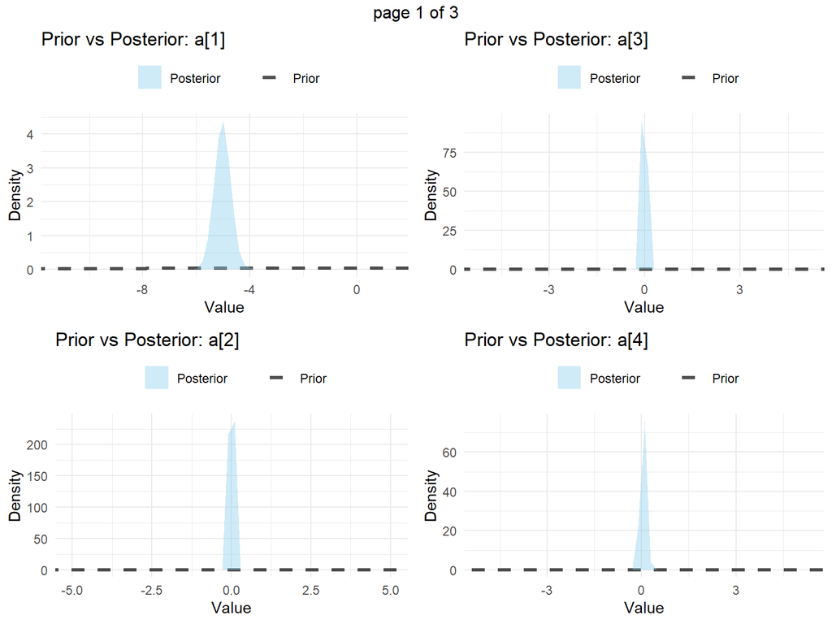

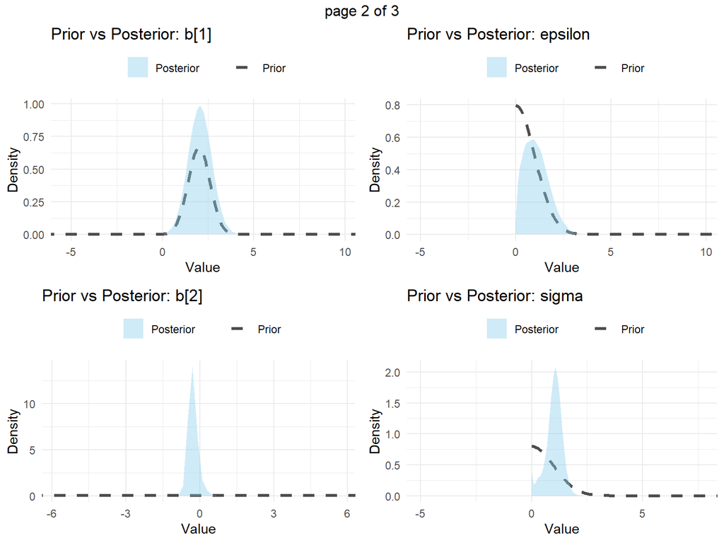

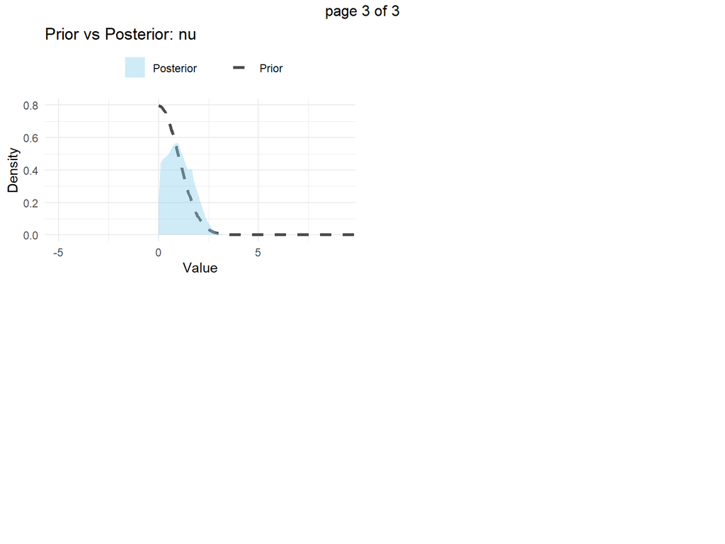

```r
plot_list <- lapply(param_names, function(param) {
  plot_prior_vs_posterior(samples = samples, param_name = param, prior_defs = prior_defs)
})
print(marrangeGrob(grobs = plot_list, nrow = 2, ncol = 2) )
```

```r
#### 3: Posterior predictive checks ###
## checking to see if  my model were true, would I be likely to see data like the data I actually observed
post_mat <- as.matrix(samples)
n_draws <- nrow(post_mat)
n_areas <- nrow(data)
```

```r
sim_y <- matrix(NA, nrow = n_draws, ncol = n_areas)
sim_z <- matrix(NA, nrow = n_draws, ncol = n_areas)
sim_mmr <- matrix(NA, nrow = n_draws, ncol = n_areas)
```

```r
## simulating reported (z) vs true (y) deaths and corresponding MMR
for (d in 1:n_draws) {
  lambda <- post_mat[d, paste0("lambda[", 1:n_areas, "]")]
  pi <- post_mat[d, paste0("pi[", 1:n_areas, "]")]

  # Simulate y_i
  y <- rpois(n_areas, lambda = lambda)
  sim_y[d, ] <- y

  # Simulate z_i
  sim_z[d, ] <- rbinom(n_areas, size = y, prob = pi)
  # e. Simulate MMR
  sim_mmr[d, ] <- y / nimble_data$live_births * 1e5
}
```

```r
par(mfrow=c(2,3))
```

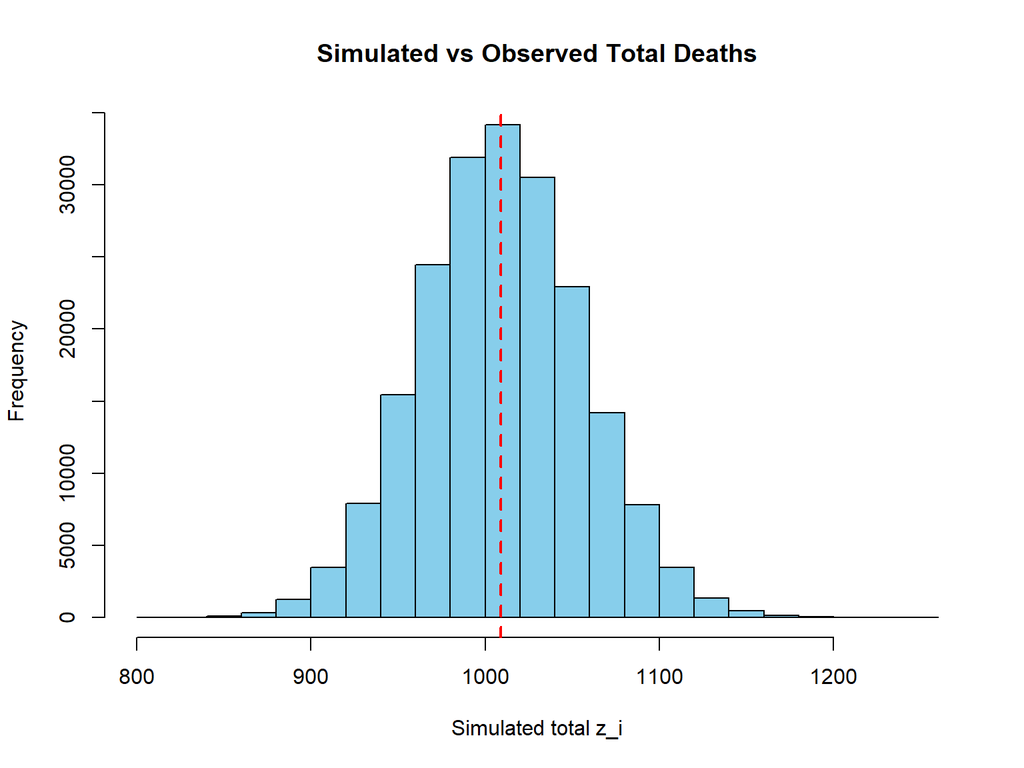

```r
### Observed vs simulated deaths (not corrected deaths )
hist(rowSums(sim_z), col = "skyblue", main = "Simulated vs Observed Total Deaths",
     xlab = "Simulated total z_i")
abline(v = sum(nimble_data$z), col = "red", lwd = 2, lty = 2)
```

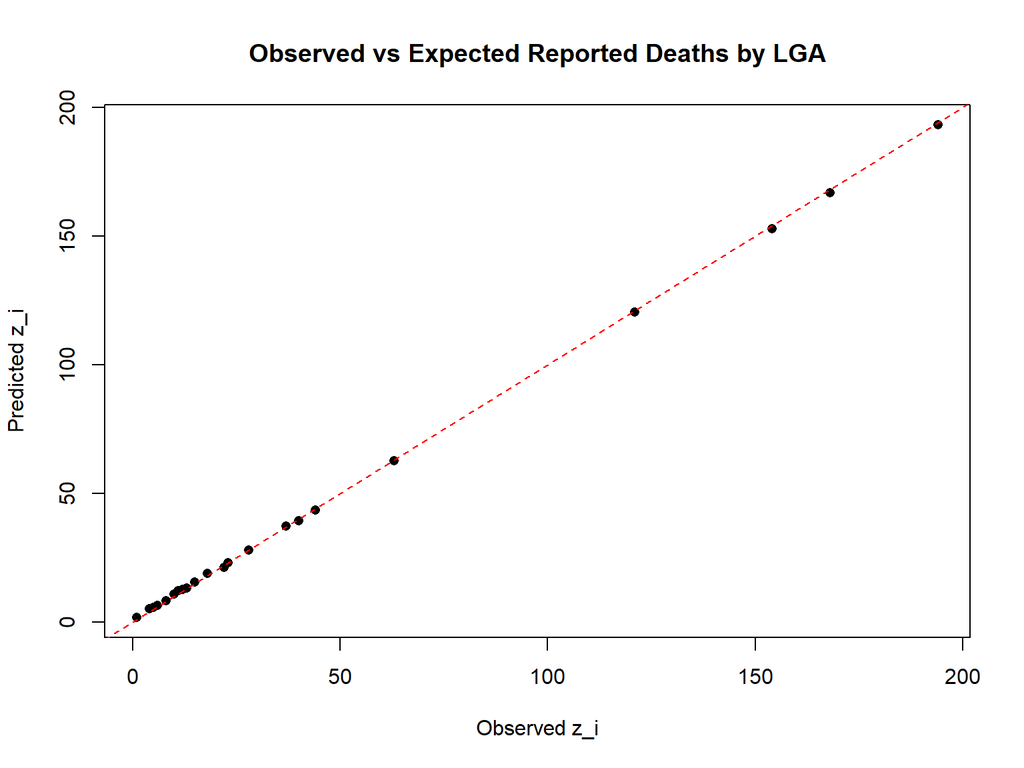

```r
plot(nimble_data$z, colMeans(sim_z), pch = 16, xlab = "Observed z_i", ylab = "Predicted z_i",
     main = "Observed vs Expected Reported Deaths by LGA")
abline(0, 1, col = "red", lty = 2)
```

```r
## coverage of observed deaths
ci_lower <- apply(sim_z, 2, quantile, 0.025)
ci_upper <- apply(sim_z, 2, quantile, 0.975)
ci_width <- ci_upper - ci_lower
```

```r
coverage <- nimble_data$z >= ci_lower & nimble_data$z <= ci_upper
mean(coverage)  # Proportion covered by 95% CrI
```

```
## [1] 1
```

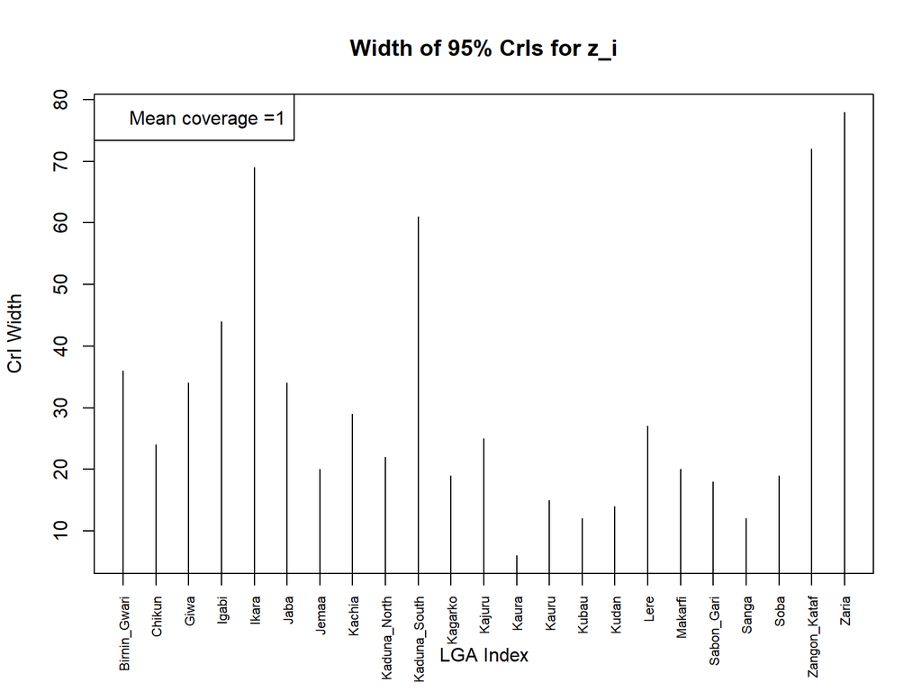

```r
plot(ci_width, type = "h", main = "Width of 95% CrIs for z_i", xlab = "LGA Index", ylab = "CrI Width",xaxt = "n")
axis(1, at = 1:length(LGA_names), labels = LGA_names, las = 2, cex.axis = 0.7)
legend("topleft",c(paste0("Mean coverage =",mean(coverage))))
```

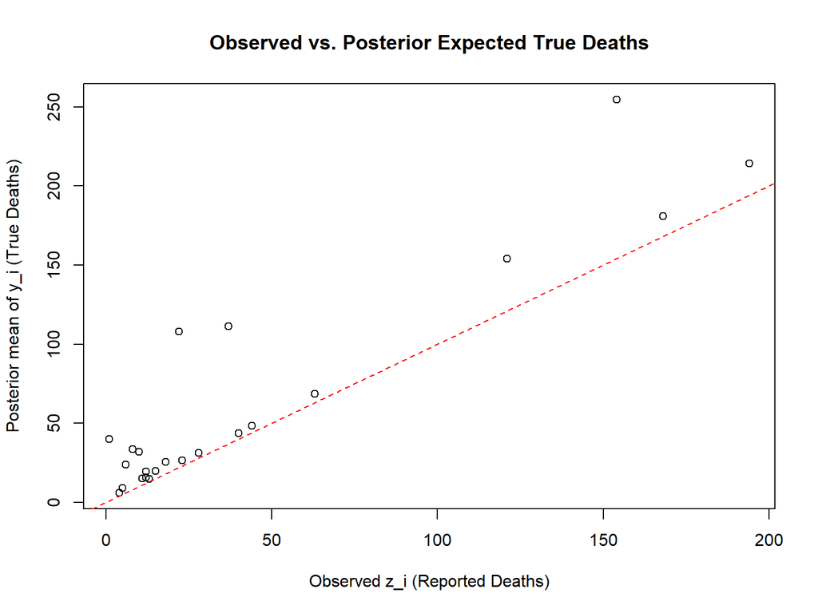

```r
## summaries of reporting
y_mean <- colMeans(sim_y)
plot(nimble_data$z, y_mean,
     xlab = "Observed z_i (Reported Deaths)", ylab = "Posterior mean of y_i (True Deaths)",
     main = "Observed vs. Posterior Expected True Deaths")
abline(0, 1, col = "red", lty = 2)
```

```r
sum(nimble_data$z > y_mean)
```

```
## [1] 0
```

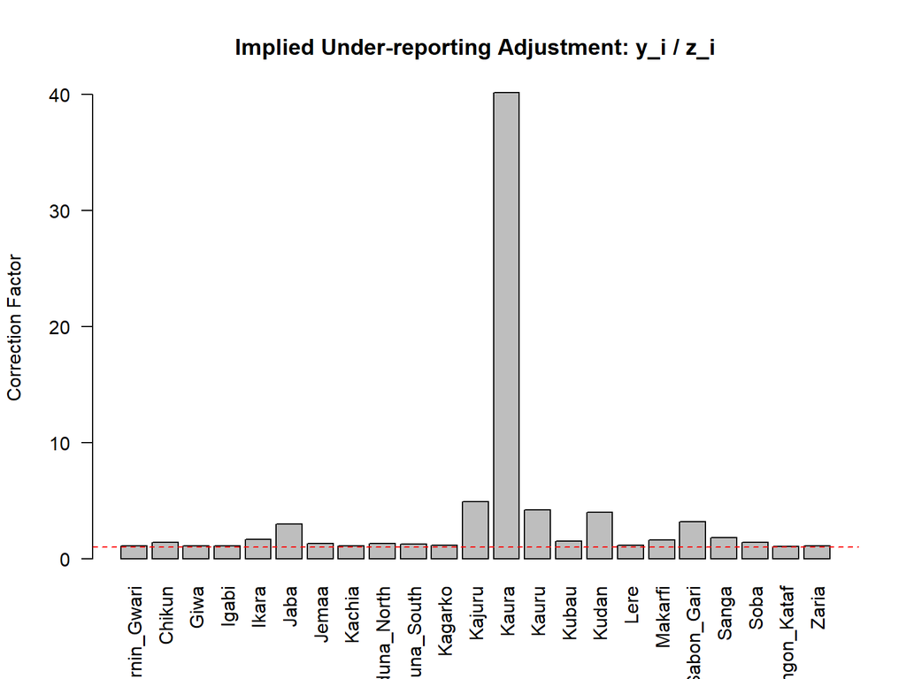

```r
## Reporting adjustment factor
ratio <- y_mean / nimble_data$z
barplot(ratio, main = "Implied Under-reporting Adjustment: y_i / z_i",
        ylab = "Correction Factor", names.arg = LGA_names, las = 2)
abline(h = 1, col = "red", lty = 2)
```

```r
par(mfrow=c(1,1))
```

```r
#### Log mean squared error
rate_z <- nimble_data$z / nimble_data$live_births
rate_z_hat <- colMeans(sim_z) / nimble_data$live_births
```

```r
lmse <- log(mean((rate_z - rate_z_hat)^2))
print(paste("LMSE =", round(lmse, 4)))
```

```
## [1] "LMSE = -17.6885"
```

```r
#### p-value for posterior predictive check
observed_total <- sum(nimble_data$z)
simulated_totals <- rowSums(sim_z)
```

```r
p_ppc <- mean(simulated_totals > observed_total)
print(paste("Posterior Predictive p-value =", round(p_ppc, 3)))
```

```
## [1] "Posterior Predictive p-value = 0.498"
```

```r
##### 3: Summary Estimates #######
samp_matrix <- as.matrix(samples)
lambda_cols <- grep("^lambda\\[[0-9]+\\]$", colnames(samp_matrix), value = TRUE)
pi_cols     <- grep("^pi\\[[0-9]+\\]$", colnames(samp_matrix), value = TRUE)
```

```r
lambda_samples <- samp_matrix[, lambda_cols]
pi_samples     <- samp_matrix[, pi_cols]
correction_samples <- 1 / pi_samples
z_samples <- lambda_samples * pi_samples
```

```r
# Extract summaries of key outcomes
y_summary   <- summarize_draws(samp_matrix, "y")
z_summary   <- summarize_draws(samp_matrix, "z")
pi_summary  <- summarize_draws(samp_matrix, "pi")
```

```r
# get births in matrix form
b_i <- nimble_data$live_births
b_matrix <- matrix(rep(b_i, each = nrow(lambda_samples)), ncol = ncol(lambda_samples), byrow = FALSE)
MMR_samples <- (lambda_samples / b_matrix) * 100000
```

```r
## Summaries of main parameters
lambda_df     <- summarize_draws(lambda_samples, "lambda")
pi_df         <- summarize_draws(pi_samples, "pi")
z_df          <- summarize_draws(z_samples, "z")
MMR_df        <- summarize_draws(MMR_samples, "MMR")
correction_df <- summarize_draws(correction_samples, "corr")
```

```r
## combining to one output
summary_df <- reduce(
  list(lambda_df, z_df, pi_df, MMR_df, correction_df),
  full_join,
  by = "LGA"
)
summary_df$LGA <- LGA_names
write.csv(summary_df,file = paste0(model_out_dir,"/summary_stats.csv"),row.names = F)
```

```r
# a full dataset that can be used to compare observed vs output vs covariates etc.
combined_df <- left_join(summary_df,data[,c("LGA","repRate","ANC_ref","lb","deaths","MMR","ever_school",
                                           "tt_mean_unweighted","ANC.4th")])
combined_df$ANC_ref_scaled <- nimble_data$ancRef
combined_df$ANC_4_scaled <- nimble_data$anc4
combined_df$tt_scaled <- nimble_data$travel
combined_df$educ_scaled <- nimble_data$educ
```

```r
#some other statistics that would be helpful
combined_df$MMR_diff <- abs(combined_df$MMR_median - combined_df$MMR)
# observed 95% CI
combined_df <- combined_df %>%
  mutate(
    MMR_obs_SE = sqrt(deaths) / lb * 100000,
    MMR_obs_lower_95 = MMR - 1.96 * MMR_obs_SE,
    MMR_obs_upper_95 = MMR + 1.96 * MMR_obs_SE
  )
```

```r
#joining with shapefile
map_out <- left_join(kdn_shp,combined_df,by=c("NAME_2"="LGA"))
combined_df$MMR_obs_CiW <- combined_df$MMR_obs_upper_95 - combined_df$MMR_obs_lower_95
combined_df$MMR_CiW <- combined_df$MMR_upper_95 - combined_df$MMR_lower_95
```

```r
###### Plots of summary statistics ##
dir.create(paste0(model_out_dir,"/plots/"))
pZobsVExpec <- ggplot(combined_df, aes(x = reorder(factor(LGA), lambda_median))) +
                  geom_point(aes(y = lambda_median, color = "Estimated")) +
                  geom_errorbar(aes(ymin = lambda_lower_95, ymax = lambda_upper_95), width = 0.2) +
                  geom_point(aes(y = deaths, color = "Observed")) +
                  labs(x = "LGA", y = "Expected Maternal Deaths (λ[i])",
                       title = "Posterior Estimates of Adjusted vs. Observed Maternal Deaths by LGA",
                       color = "Type") +
                  theme_minimal() +
                  theme(axis.text.x = element_text(angle = 45, hjust = 1)) +
                  scale_color_manual(values = c("Estimated" = "black", "Observed" = "red"),name = NULL)
```

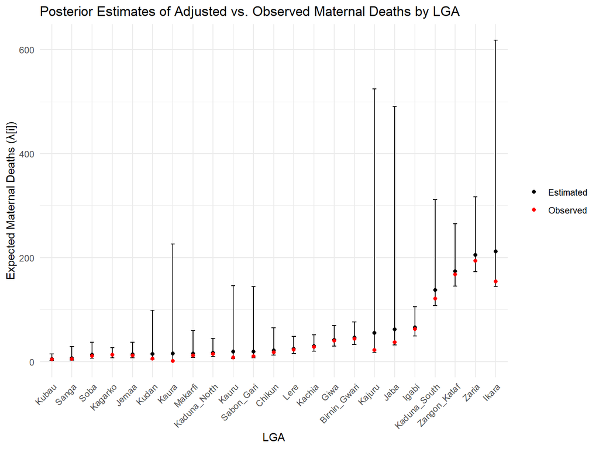

```r
pZobsVExpec
```

```r
pMMRobsVExpec <- ggplot(combined_df, aes(x = reorder(factor(LGA), MMR_diff))) +
  geom_point(aes(y = MMR_median, color = "Estimated")) +
  geom_errorbar(aes(ymin = MMR_lower_95, ymax = MMR_upper_95), width = 0.2) +
  geom_point(aes(y = MMR, color = "Observed")) +
  labs(x = "LGA", y = "MMR",
       title = "Posterior Estimates of Adjusted vs. Observed MMR by LGA",
       color = "Type") +
  theme_minimal() +
  theme(axis.text.x = element_text(angle = 45, hjust = 1)) +
  scale_color_manual(values = c("Estimated" = "black", "Observed" = "red"),name = NULL)
```

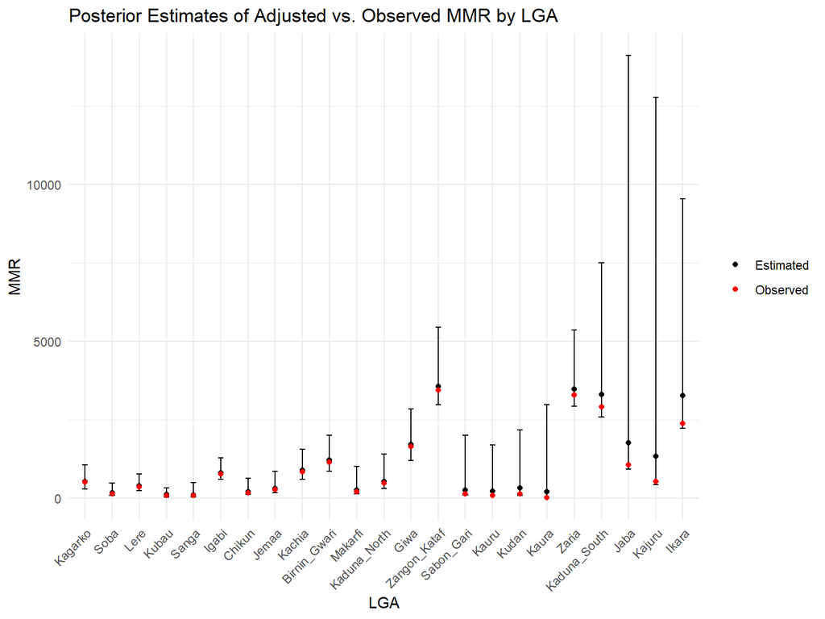

```r
pMMRobsVExpec
```

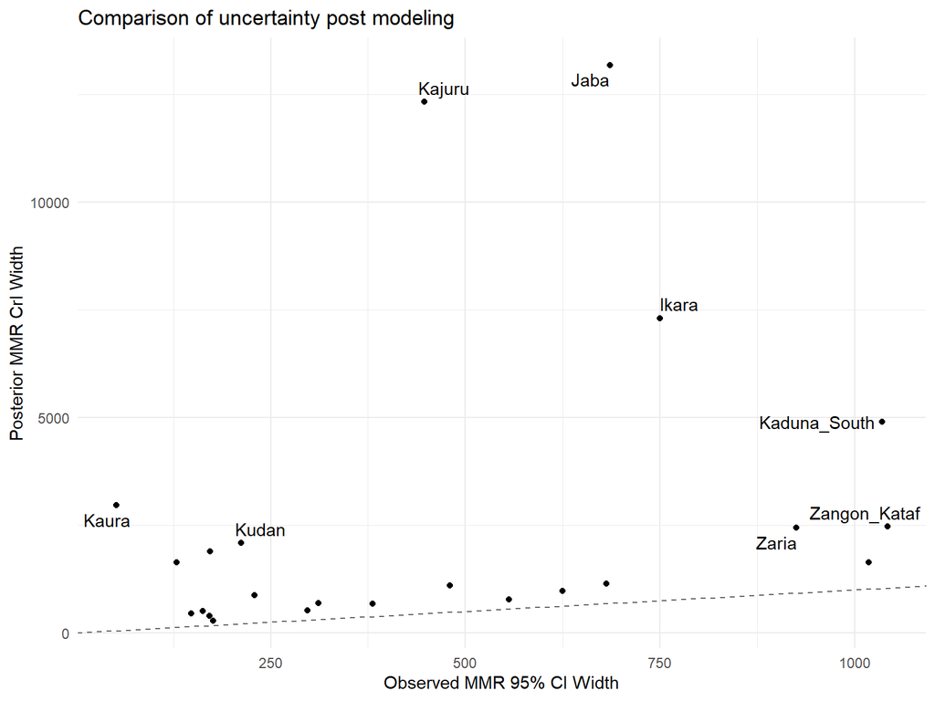

```r
pMMRCrIWidth <- ggplot(combined_df,aes(y=MMR_CiW, x = MMR_obs_CiW)) +
  geom_point() +
  labs(x = "Observed MMR 95% CI Width", y = "Posterior MMR CrI Width",
       title = "Comparison of uncertainty post modeling") +
  geom_abline(slope = 1, intercept = 0, linetype = "dashed", color = "gray40") +
  geom_text_repel(data = filter(combined_df, MMR_CiW > 2000), aes(label = LGA)) +
  theme_minimal()
pMMRCrIWidth
```

```r
pRepAdjust <- ggplot(combined_df, aes(x = reorder(factor(LGA), pi_median), y = pi_median)) +
  geom_point() +
  geom_errorbar(aes(ymin = pi_lower_95, ymax = pi_upper_95), width = 0.2) +
  labs(x = "LGA", y = "Reporting Rate (pi)",
       title = "Estimated Median Posterior Reporting Rate by LGA") +
  theme_minimal() +
  theme(axis.text.x = element_text(angle = 45, hjust = 1))
```

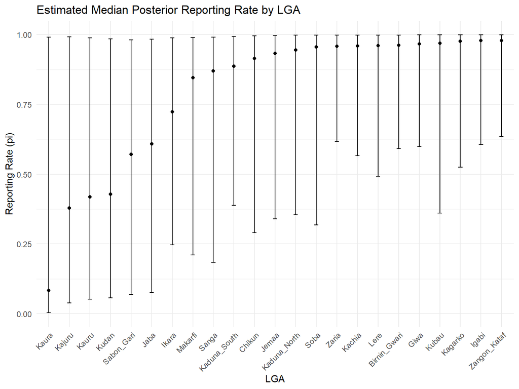

```r
pRepAdjust
```

```r
###### Maps of summary statistics ####
dir.create(paste0(model_out_dir,"/maps/"))
#High burden LGAs
pLambdamap <- ggplot(map_out) +
  geom_sf(aes(fill = lambda_median )) +
  scale_fill_gradientn(
    colors = c("#7FB77E", "#F7DC6F", "#E74C3C"),
    name = "Deaths") +
  geom_sf_text(aes(label = NAME_2 ), size = 4, check_overlap = TRUE,color="white",fontface ="bold") +
  theme_void() +
  labs(fill = "Deaths",
       title = "Posterior Median Maternal Deaths (Adjusted for Under-reporting)")
```

```r
pMMR <- ggplot(map_out) +
  geom_sf(aes(fill = MMR_median )) +
  scale_fill_gradientn(
    colors = c("#7FB77E", "#F7DC6F", "#E74C3C"),
    name = "MMR") +
  geom_sf_text(aes(label = NAME_2 ), size = 4, check_overlap = TRUE,color="white",fontface ="bold") +
  theme_void() +
  labs(fill = "MMR (per 100k LB)",
       title = "Posterior median MMR (Adjusted for Under-reporting)")
```

```r
pMMRObs <- ggplot(map_out) +
  geom_sf(aes(fill = MMR )) +
  scale_fill_gradientn(
    colors = c("#7FB77E", "#F7DC6F", "#E74C3C"),
    name = "MMR") +
  geom_sf_text(aes(label = NAME_2 ), size = 4, check_overlap = TRUE,color="white",fontface ="bold") +
  theme_void() +
  labs(fill = "MMR (per 100k LB)",
       title = "Observed MMR")
```

```r
pRiskBurdenMap <- pLambdamap + pMMR + pMMRObs +plot_layout(ncol = 2)
```

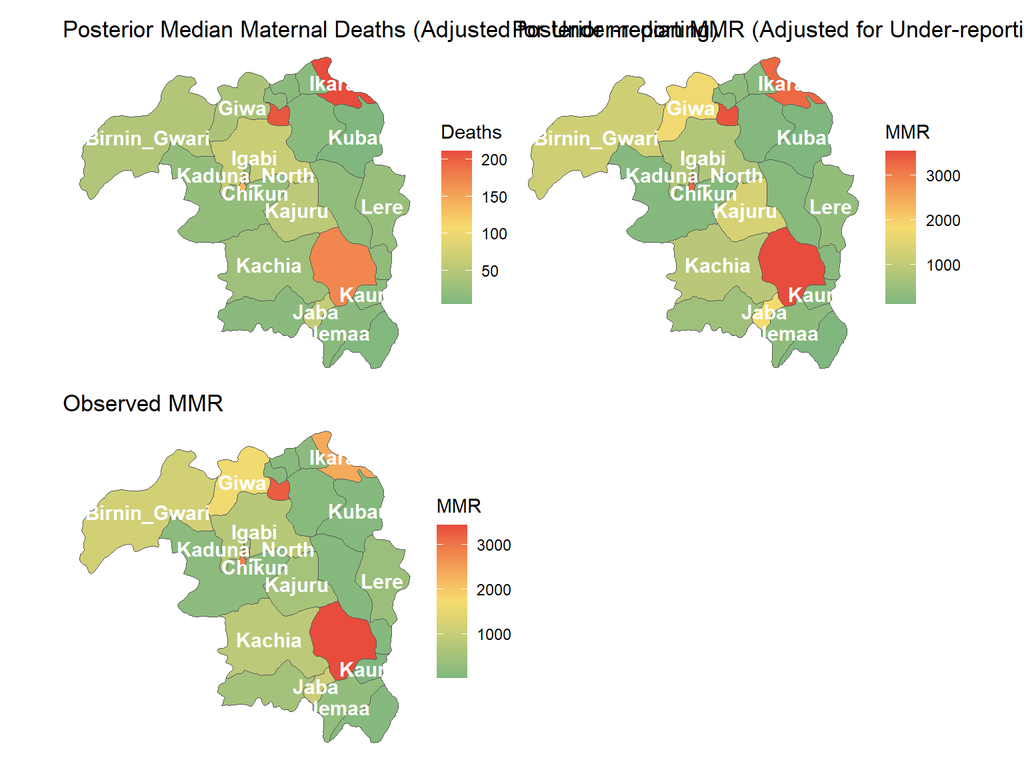

```r
pRiskBurdenMap
```

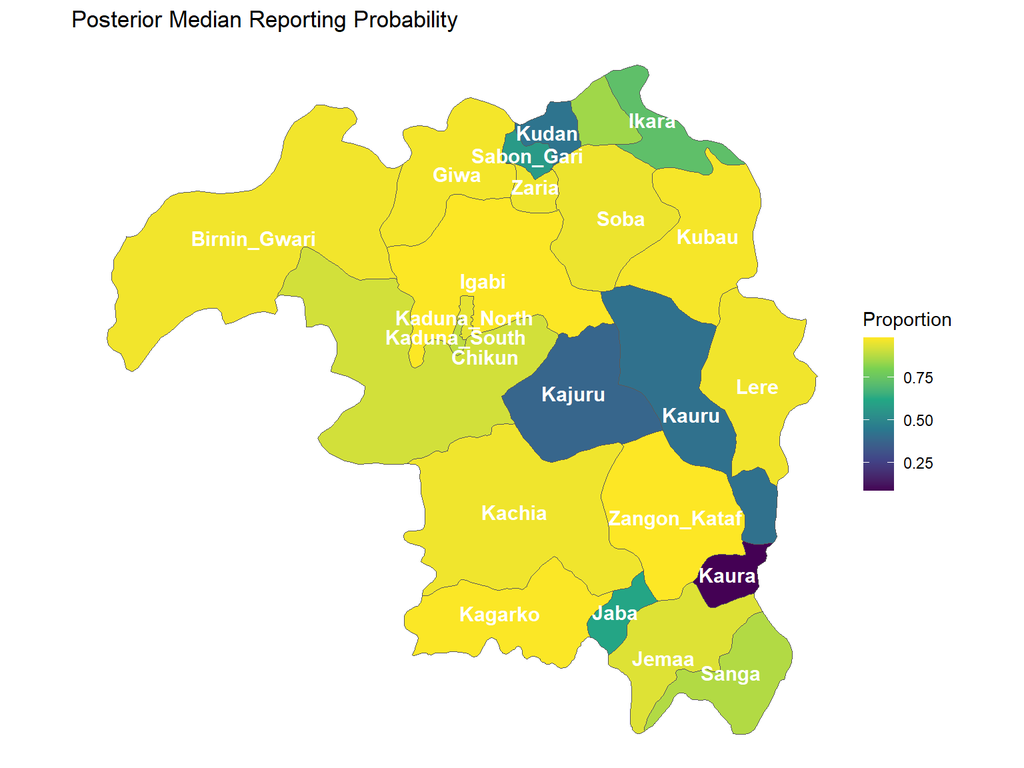

```r
pRepMap <- ggplot(map_out) +
  geom_sf(aes(fill = pi_median )) +
  scale_fill_viridis_c() +
  geom_sf_text(aes(label = NAME_2 ), size = 4, check_overlap = TRUE,color="white",fontface ="bold") +
  theme_void() +
  labs(fill = "Proportion",
       title = "Posterior Median Reporting Probability")
pRepMap
```

```r
##### Comparison of incidence/reporting to predictors
pRepPred <- ggplot(combined_df, aes(x = ANC_ref_scaled, y = pi_median)) +
              geom_point() +
              geom_smooth(method = "lm", se = FALSE, color = "blue") +
              labs(x = "ANC Reporting Covariate (Scaled)",
                   y = "Posterior Median of π[i]",
                   title = "Correlation between Reporting Predictors and Covariates") +
              geom_text_repel(data = filter(combined_df, pi_median < 0.6), aes(label = LGA)) +
              theme_minimal()
```

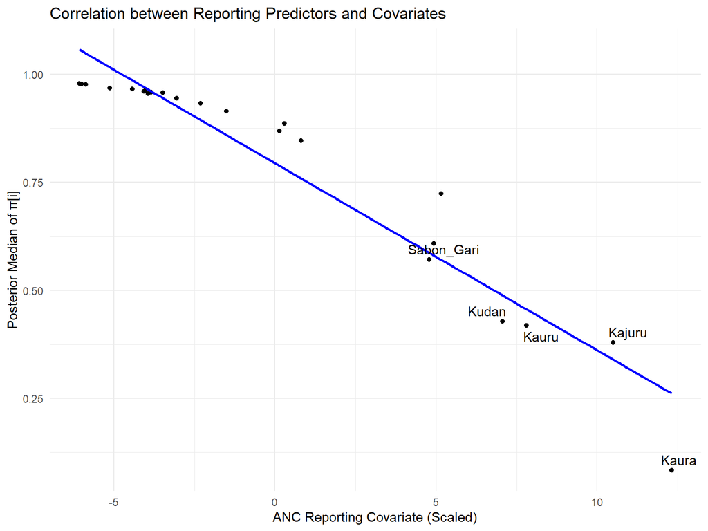

```r
pRepPred
```

```r
#### Spatial vs unstructured effects for incidence
# Get phi and theta column names
phi_cols <- grep("^phi\\[[0-9]+\\]$", colnames(post_mat), value = TRUE)
theta_cols <- grep("^theta\\[[0-9]+\\]$", colnames(post_mat), value = TRUE)
```

```r
# Extract posterior samples & summarize
phi_samples <- post_mat[, phi_cols]
theta_samples <- post_mat[, theta_cols]
tau_samples <- post_mat[, "tau"]
```

```r
phi_df <- summarize_draws(phi_samples, "phi")
phi_df$LGA <- LGA_names
theta_df <- summarize_draws(theta_samples, "theta")
theta_df$LGA <- LGA_names
```

```r
## add to output data
combined_df <- combined_df %>%
  left_join(phi_df, by = "LGA") %>%
  left_join(theta_df, by = "LGA")
```

```r
map_out <- map_out  %>%
  left_join(phi_df, by = c("NAME_2"="LGA")) %>%
  left_join(theta_df, by = c("NAME_2"="LGA"))
```

```r
### Proportion of variation explained by spatial random effect
Var_phi <- var(combined_df$phi_mean)
Var_theta <- var(combined_df$theta_mean)
Var_spatial <- Var_phi + Var_theta
p_phi <- Var_phi / Var_spatial
```

```r
## posteriors of phi & theta
phi_df <- as.data.frame(phi_samples)
phi_df$draw <- seq_len(nrow(phi_df))
```

```r
theta_df <- as.data.frame(theta_samples)
theta_df$draw <- seq_len(nrow(theta_df))
```

```r
theta_df <- as.data.frame(theta_samples)
theta_df$draw <- seq_len(nrow(theta_df))
```

```r
# Reshape to long format for both phi and theta
phi_long <- phi_df %>%
  pivot_longer(
    cols = -draw,  # exclude 'draw' from pivoting
    names_to = "param",
    values_to = "phi_draw"
  ) %>%
  mutate(LGA = as.integer(gsub("phi\\[|\\]", "", param)))
phi_long <- left_join(phi_long,LGA_names2,by="LGA")
```

```r
theta_long <- theta_df %>%
  pivot_longer(-draw, names_to = "param", values_to = "theta_draw") %>%
  mutate(LGA = as.integer(gsub("theta\\[|\\]", "", param)))
theta_long <- left_join(theta_long,LGA_names2,by="LGA")
```

```r
pPhiPOst <- ggplot(phi_long, aes(x = phi_draw)) +
              geom_density(fill = "steelblue", alpha = 0.6) +
              facet_wrap(~ name, scales = "free", ncol = 6) +
              geom_vline(xintercept = 0, linetype = "dashed") +
              labs(title = "Posterior Distributions of Structured Spatial Effects (φ[i])",
                   x = "φ[i]", y = "Density") +
              theme_minimal()
```

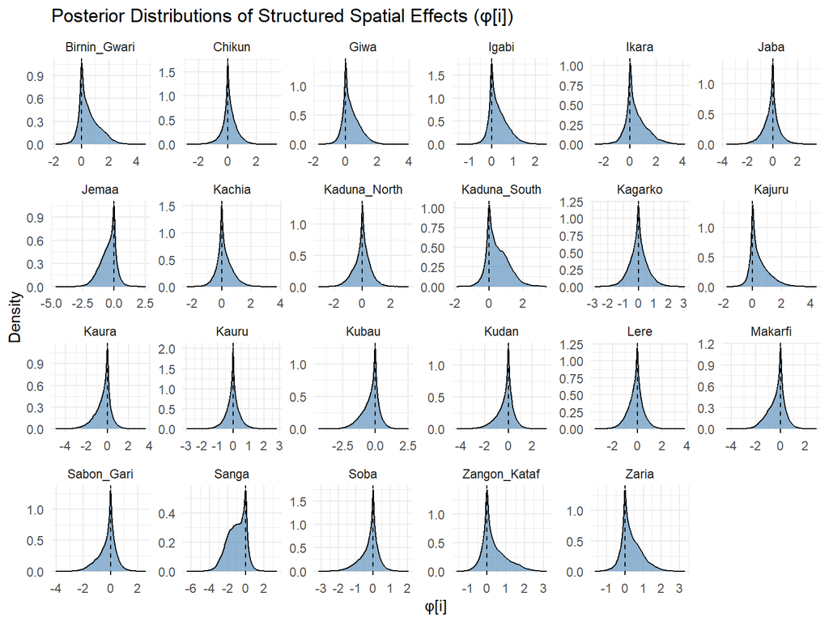

```r
pPhiPOst
```

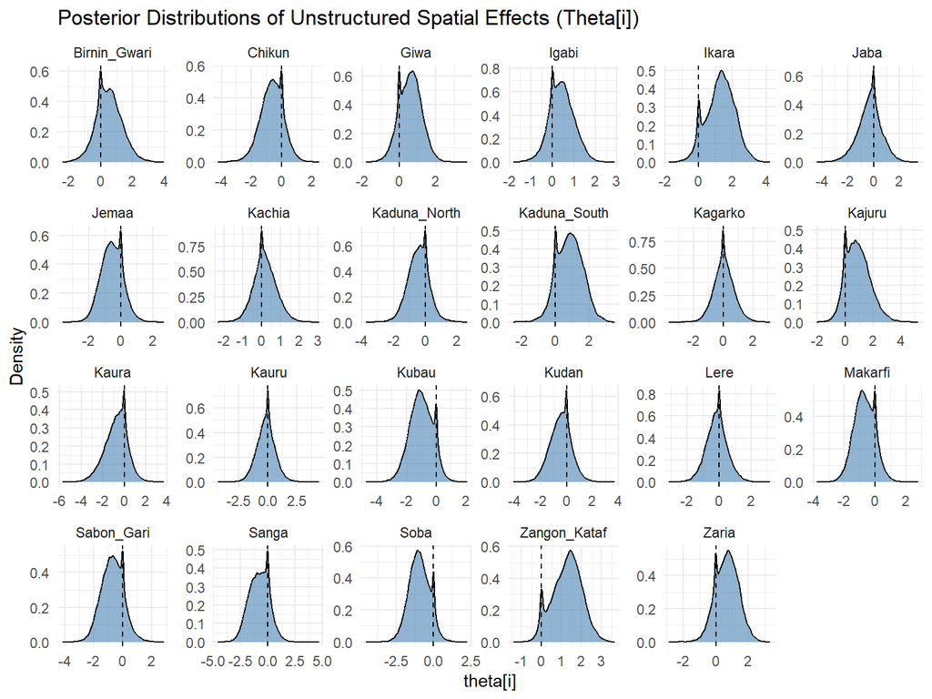

```r
pThetaPOst <- ggplot(theta_long, aes(x = theta_draw)) +
  geom_density(fill = "steelblue", alpha = 0.6) +
  facet_wrap(~ name, scales = "free", ncol = 6) +
  geom_vline(xintercept = 0, linetype = "dashed") +
  labs(title = "Posterior Distributions of Unstructured Spatial Effects (Theta[i])",
       x = "theta[i]", y = "Density") +
  theme_minimal()
pThetaPOst
```